# White Wine Analysis

# Disclaimer :

### This tidy data set contains 4,898 white wines with 11 variables on quantifying the chemical properties of each wine. At least 3 wine experts rated the quality of each wine, providing a rating between 0 (very bad) and 10 (very excellent). In This project we want to discover what is chemical properties affect white wine quality.

# Univariate Plots Section

```
## [1] 4898
```

```
## [1] 13
```

```
##     X fixed.acidity volatile.acidity citric.acid residual.sugar chlorides
## 1   1           7.0             0.27        0.36           20.7     0.045
## 2   2           6.3             0.30        0.34            1.6     0.049
## 3   3           8.1             0.28        0.40            6.9     0.050
## 4   4           7.2             0.23        0.32            8.5     0.058
## 5   5           7.2             0.23        0.32            8.5     0.058
## 6   6           8.1             0.28        0.40            6.9     0.050
## 7   7           6.2             0.32        0.16            7.0     0.045
## 8   8           7.0             0.27        0.36           20.7     0.045
## 9   9           6.3             0.30        0.34            1.6     0.049
## 10 10           8.1             0.22        0.43            1.5     0.044
##    free.sulfur.dioxide total.sulfur.dioxide density   pH sulphates alcohol
## 1                   45                  170  1.0010 3.00      0.45     8.8
## 2                   14                  132  0.9940 3.30      0.49     9.5
## 3                   30                   97  0.9951 3.26      0.44    10.1
```

[output cut: 18 more lines]

```
##         X fixed.acidity volatile.acidity citric.acid residual.sugar
## 4891 4891           6.1             0.34        0.29            2.2
## 4892 4892           5.7             0.21        0.32            0.9
## 4893 4893           6.5             0.23        0.38            1.3
## 4894 4894           6.2             0.21        0.29            1.6
## 4895 4895           6.6             0.32        0.36            8.0
## 4896 4896           6.5             0.24        0.19            1.2
## 4897 4897           5.5             0.29        0.30            1.1
## 4898 4898           6.0             0.21        0.38            0.8
##      chlorides free.sulfur.dioxide total.sulfur.dioxide density   pH
## 4891     0.036                  25                  100 0.98938 3.06
## 4892     0.038                  38                  121 0.99074 3.24
## 4893     0.032                  29                  112 0.99298 3.29
## 4894     0.039                  24                   92 0.99114 3.27
## 4895     0.047                  57                  168 0.99490 3.15
## 4896     0.041                  30                  111 0.99254 2.99
## 4897     0.022                  20                  110 0.98869 3.34
## 4898     0.020                  22                   98 0.98941 3.26
##      sulphates alcohol quality
## 4891      0.44    11.8       6
## 4892      0.46    10.6       6
## 4893      0.54     9.7       5
## 4894      0.50    11.2       6
## 4895      0.46     9.6       5
## 4896      0.46     9.4       6
## 4897      0.38    12.8       7
## 4898      0.32    11.8       6
```

```
##        X        fixed.acidity    volatile.acidity  citric.acid
##  Min.   :   1   Min.   : 3.800   Min.   :0.0800   Min.   :0.0000
##  1st Qu.:1225   1st Qu.: 6.300   1st Qu.:0.2100   1st Qu.:0.2700
##  Median :2450   Median : 6.800   Median :0.2600   Median :0.3200
##  Mean   :2450   Mean   : 6.855   Mean   :0.2782   Mean   :0.3342
##  3rd Qu.:3674   3rd Qu.: 7.300   3rd Qu.:0.3200   3rd Qu.:0.3900
##  Max.   :4898   Max.   :14.200   Max.   :1.1000   Max.   :1.6600
##  residual.sugar     chlorides       free.sulfur.dioxide
##  Min.   : 0.600   Min.   :0.00900   Min.   :  2.00
##  1st Qu.: 1.700   1st Qu.:0.03600   1st Qu.: 23.00
##  Median : 5.200   Median :0.04300   Median : 34.00
##  Mean   : 6.391   Mean   :0.04577   Mean   : 35.31
##  3rd Qu.: 9.900   3rd Qu.:0.05000   3rd Qu.: 46.00
##  Max.   :65.800   Max.   :0.34600   Max.   :289.00
##  total.sulfur.dioxide    density             pH          sulphates
##  Min.   :  9.0        Min.   :0.9871   Min.   :2.720   Min.   :0.2200
##  1st Qu.:108.0        1st Qu.:0.9917   1st Qu.:3.090   1st Qu.:0.4100
##  Median :134.0        Median :0.9937   Median :3.180   Median :0.4700
##  Mean   :138.4        Mean   :0.9940   Mean   :3.188   Mean   :0.4898
##  3rd Qu.:167.0        3rd Qu.:0.9961   3rd Qu.:3.280   3rd Qu.:0.5500
##  Max.   :440.0        Max.   :1.0390   Max.   :3.820   Max.   :1.0800
##     alcohol         quality
##  Min.   : 8.00   Min.   :3.000
##  1st Qu.: 9.50   1st Qu.:5.000
##  Median :10.40   Median :6.000
##  Mean   :10.51   Mean   :5.878
##  3rd Qu.:11.40   3rd Qu.:6.000
##  Max.   :14.20   Max.   :9.000
```

```
## 'data.frame':    4898 obs. of  13 variables:
##  $ X                   : int  1 2 3 4 5 6 7 8 9 10 ...
##  $ fixed.acidity       : num  7 6.3 8.1 7.2 7.2 8.1 6.2 7 6.3 8.1 ...
##  $ volatile.acidity    : num  0.27 0.3 0.28 0.23 0.23 0.28 0.32 0.27 0.3 0.22 ...
##  $ citric.acid         : num  0.36 0.34 0.4 0.32 0.32 0.4 0.16 0.36 0.34 0.43 ...
##  $ residual.sugar      : num  20.7 1.6 6.9 8.5 8.5 6.9 7 20.7 1.6 1.5 ...
##  $ chlorides           : num  0.045 0.049 0.05 0.058 0.058 0.05 0.045 0.045 0.049 0.044 ...
##  $ free.sulfur.dioxide : num  45 14 30 47 47 30 30 45 14 28 ...
##  $ total.sulfur.dioxide: num  170 132 97 186 186 97 136 170 132 129 ...
##  $ density             : num  1.001 0.994 0.995 0.996 0.996 ...
##  $ pH                  : num  3 3.3 3.26 3.19 3.19 3.26 3.18 3 3.3 3.22 ...
##  $ sulphates           : num  0.45 0.49 0.44 0.4 0.4 0.44 0.47 0.45 0.49 0.45 ...
##  $ alcohol             : num  8.8 9.5 10.1 9.9 9.9 10.1 9.6 8.8 9.5 11 ...
##  $ quality             : int  6 6 6 6 6 6 6 6 6 6 ...
```

```
##    Min. 1st Qu.  Median    Mean 3rd Qu.    Max.
##   3.800   6.300   6.800   6.855   7.300  14.200
```

```
##    Min. 1st Qu.  Median    Mean 3rd Qu.    Max.
##  0.0800  0.2100  0.2600  0.2782  0.3200  1.1000
```

```
##    Min. 1st Qu.  Median    Mean 3rd Qu.    Max.
##  0.0000  0.2700  0.3200  0.3342  0.3900  1.6600
```

**As we can see from the summary fuction, Violate acidity, and citric acid recorded the lowest amont compared to fixed acidity** **The fixed acidity recorded mean with 6.855 approximatily, and maximum level with 14, which data ranged between 3 to 14.** **The volatile acidity recorded mean with 0.278 approximatily, and maximum level with 1.1000, which data ranged between 0.0800 to 1.1000.** **The citric acid recorded mean with 0.334 approximatily, and maximum level with 1.6600, which data ranged between 0.0000 to 1.6600.**

**We still need to discover more to figure out the quality of white wine.**

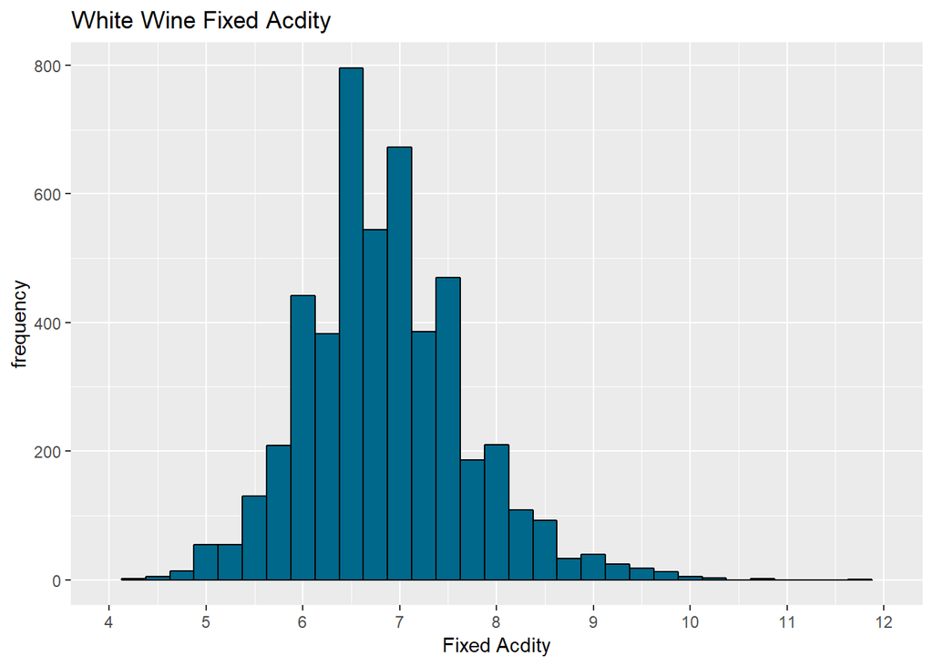

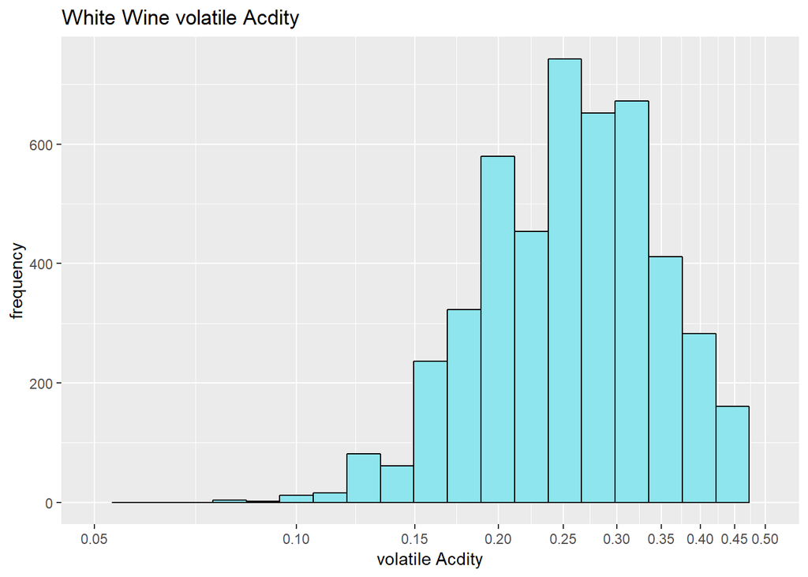

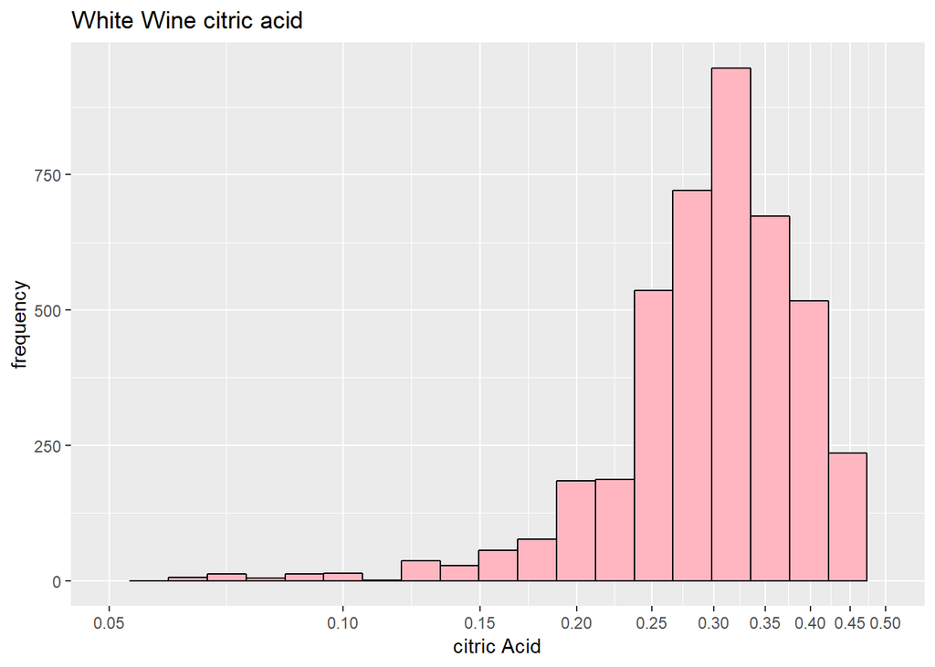

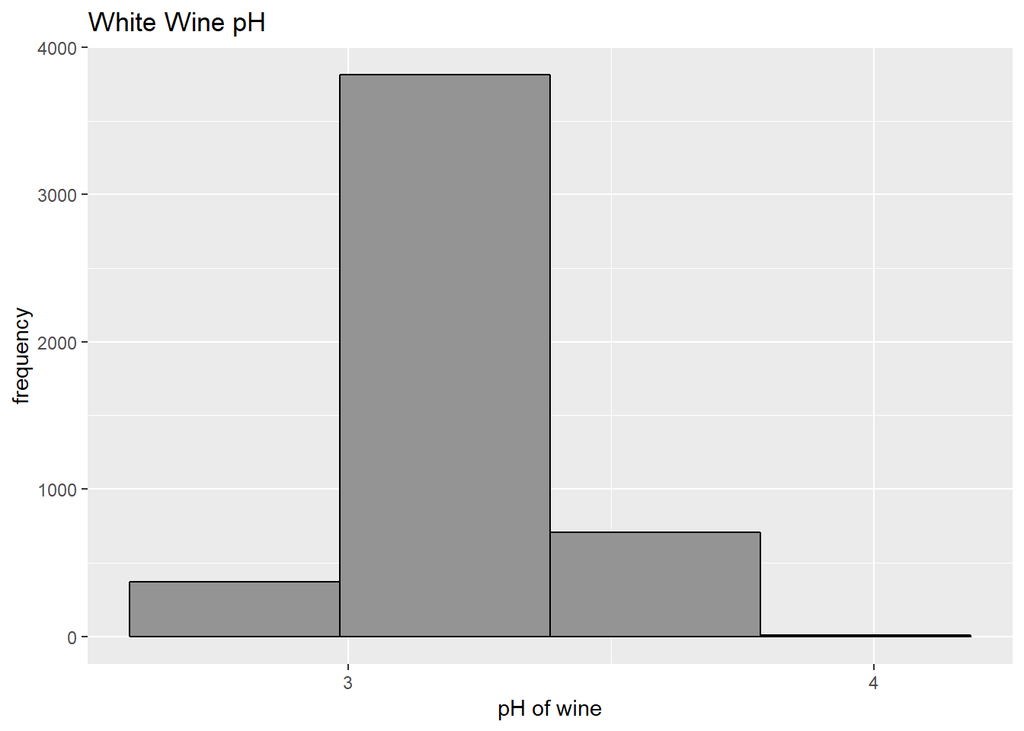

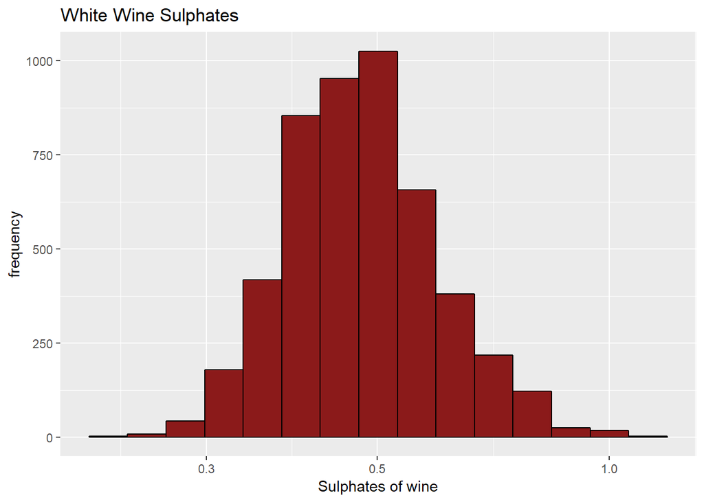

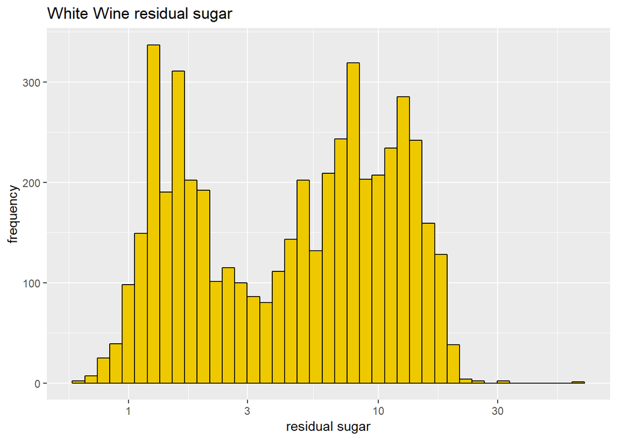

**From the previous charts , pH rate, sulphates rate and residual sugar we can notes that pH of white wine have highest number with 4000 on 3 of pH, and sulphates rate we notes that white wine recorded highest rate with 1000 on 0.5 of sulphates.Finally, residual of sugar we can notes sudenly increasing and dicreading.**

# Univariate Analysis

### What is/are the main feature(s) of interest in your dataset?

**I am interested in discovering the quality and the rate of chloride and pH of white wine.**

### What other features in the dataset do you think will help support your investigation into your feature(s) of interest?

**Type of acidity such citric and volatile acid**

### Did you create any new variables from existing variables in the dataset?

```
##
##    3    4    5    6    7    8    9
##   20  163 1457 2198  880  175    5
```

### Of the features you investigated, were there any unusual distributions? Did you perform any operations on the data to tidy, adjust, or change the form of the data? If so, why did you do this?

**I did not find unusual content on the charts.**

# Bivariate Plots Section

```
##    Min. 1st Qu.  Median    Mean 3rd Qu.    Max.
##    2.00   23.00   34.00   35.31   46.00  289.00
```

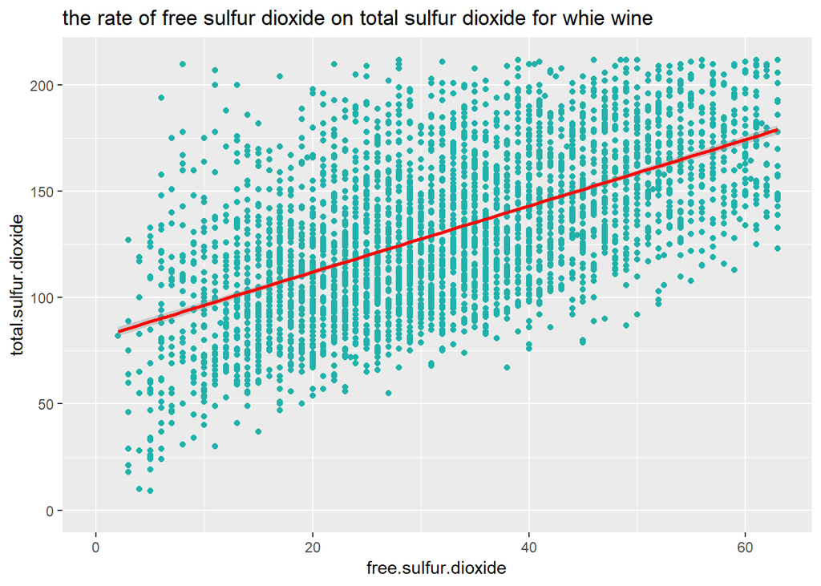

```
##
##  Pearson's product-moment correlation
##
## data:  wqw$free.sulfur.dioxide and wqw$total.sulfur.dioxide
## t = 54.645, df = 4896, p-value < 2.2e-16
## alternative hypothesis: true correlation is not equal to 0
## 95 percent confidence interval:
##  0.5977994 0.6326026
## sample estimates:
##      cor
## 0.615501
```

**In this scatter chart we want to discover the relationship among free sulfur dioxide and total sulfur dioxide, as we can see after calculating the correlation=0.615501, which is higher than 0.5, so it is modarate relation.**

# Bivariate Analysis

### Did you observe any interesting relationships between the other features (not the main feature(s) of interest)?

- **The relationship of sulfur content have the moderate relatins.**

### What was the strongest relationship you found?

# Multivariate Plots Section

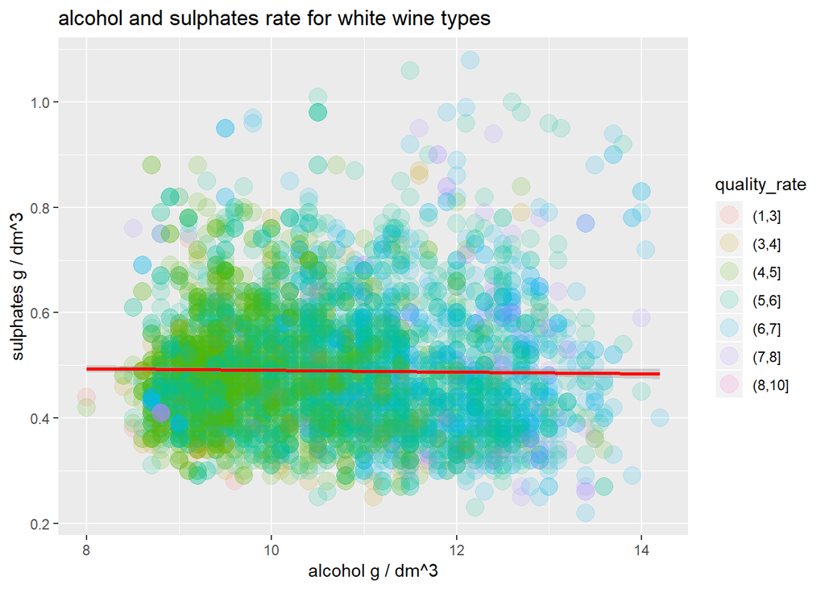

```
##
##  Pearson's product-moment correlation
##
## data:  wqw$alcohol and wqw$sulphates
## t = -1.22, df = 4896, p-value = 0.2225
## alternative hypothesis: true correlation is not equal to 0
## 95 percent confidence interval:
##  -0.04541705  0.01057885
## sample estimates:
##         cor
## -0.01743277
```

**we can illustrate that, the relationship among alcohol and sulphates for each type of white wine have a negative weak relation with -0.0174 correlation.**

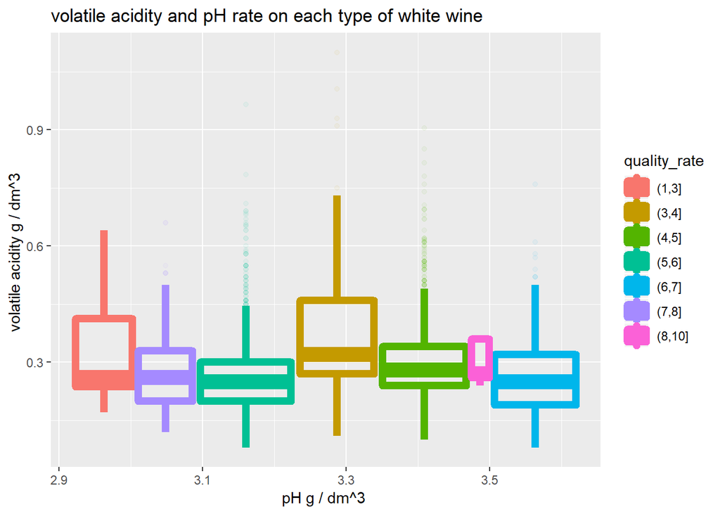

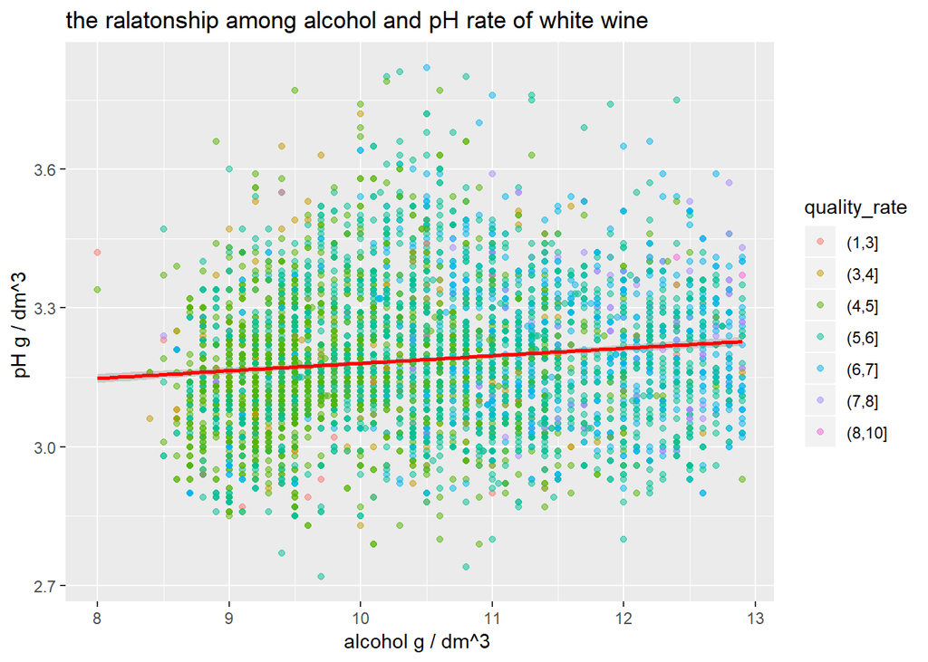

```
##
##  Pearson's product-moment correlation
##
## data:  wqw$alcohol and wqw$pH
## t = 8.5601, df = 4896, p-value < 2.2e-16
## alternative hypothesis: true correlation is not equal to 0
## 95 percent confidence interval:
##  0.09374446 0.14893205
## sample estimates:
##       cor
## 0.1214321
```

**in this chart we want to descover the relationship among pH and alcohol rate on ewach type of white wine, and after calculating the correlation we can see that 0.1214 is less that 0.3 which is weak ralationship**

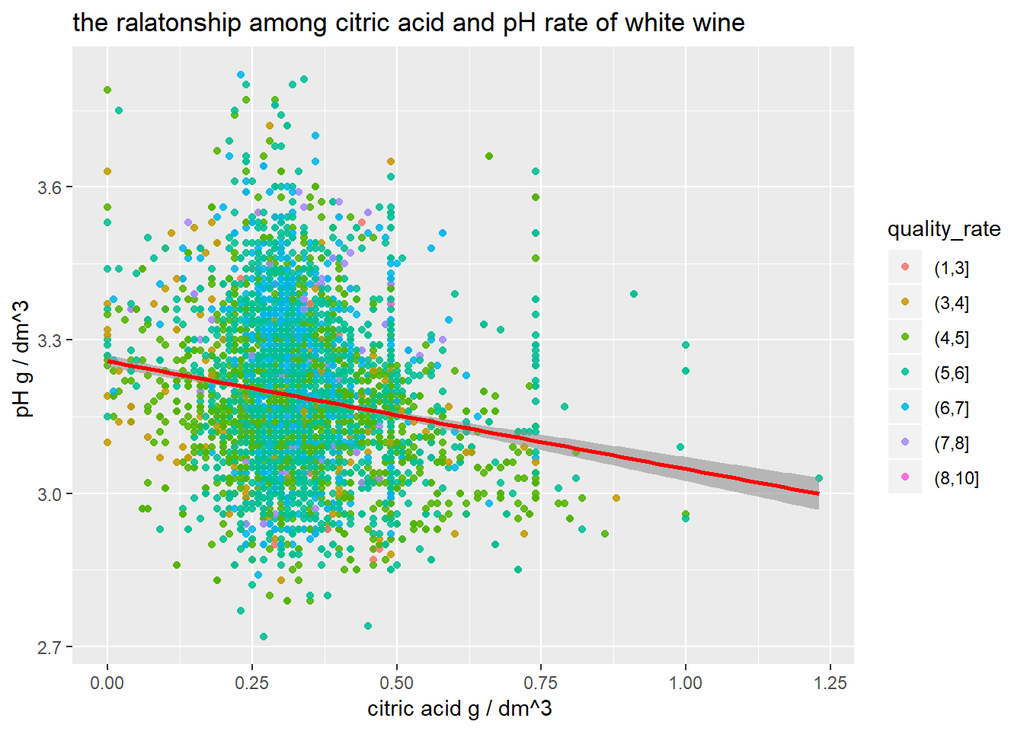

```
##
##  Pearson's product-moment correlation
##
## data:  wqw$citric.acid and wqw$pH
## t = -11.614, df = 4896, p-value < 2.2e-16
## alternative hypothesis: true correlation is not equal to 0
## 95 percent confidence interval:
##  -0.1908793 -0.1363671
## sample estimates:
##        cor
## -0.1637482
```

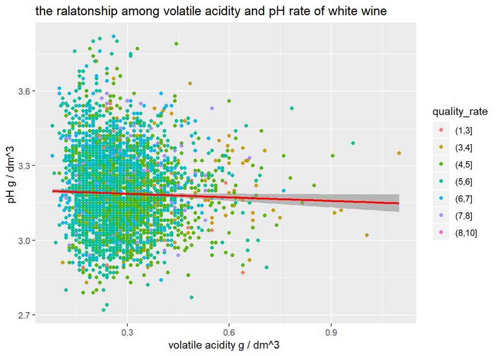

```
##
##  Pearson's product-moment correlation
##
## data:  wqw$volatile.acidity and wqw$pH
## t = -2.2343, df = 4896, p-value = 0.02551
## alternative hypothesis: true correlation is not equal to 0
## 95 percent confidence interval:
##  -0.059868312 -0.003912409
## sample estimates:
##         cor
## -0.03191537
```

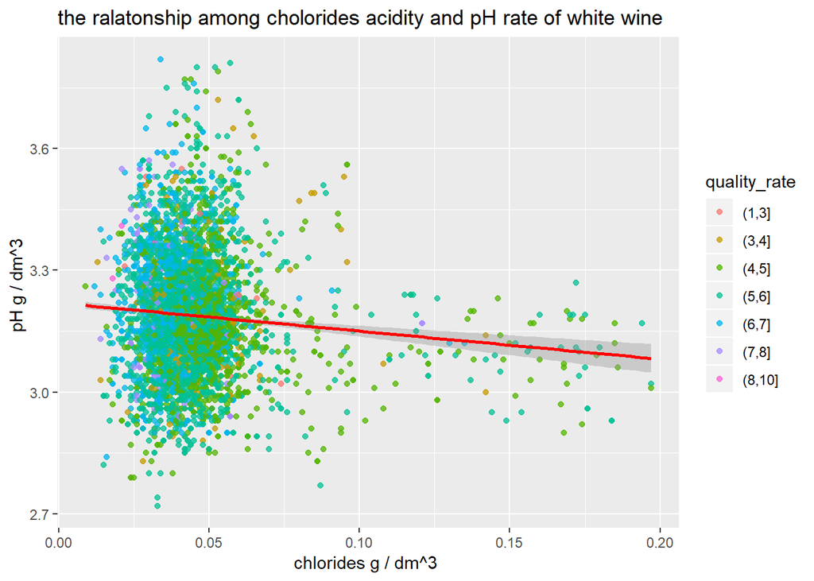

```
##
##  Pearson's product-moment correlation
##
## data:  wqw$chlorides and wqw$pH
## t = -6.3542, df = 4896, p-value = 2.285e-10
## alternative hypothesis: true correlation is not equal to 0
## 95 percent confidence interval:
##  -0.11814666 -0.06259154
## sample estimates:
##         cor
## -0.09043946
```

# Multivariate Analysis

### Were there any interesting or surprising interactions between features?

**Before starting analysis I guessed that the relations among acidity and pH will be string relations, after calculating the correlations and displaying the charts I find it as a weak relations.**

# Final Plots and Summary

### Plot One

[figure not shown]

```
##
##  Pearson's product-moment correlation
##
## data:  wqw$chlorides and wqw$residual.sugar
## t = 6.2299, df = 4896, p-value = 5.057e-10
## alternative hypothesis: true correlation is not equal to 0
## 95 percent confidence interval:
##  0.06082916 0.11640188
## sample estimates:
##        cor
## 0.08868454
```

### Description One

**The correlation ais equal 0.088 which is less than 0.3, the the relations among chlorides and residual of sugar is very weak relations**

### Plot Two

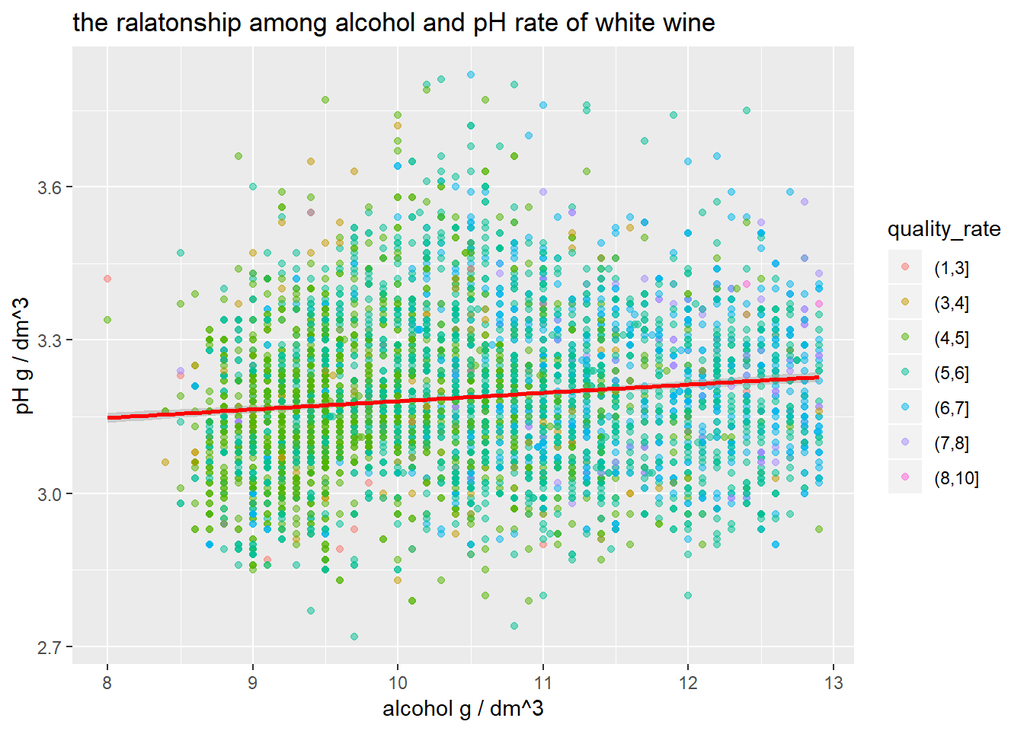

```
##
##  Pearson's product-moment correlation
##
## data:  wqw$alcohol and wqw$pH
## t = 8.5601, df = 4896, p-value < 2.2e-16
## alternative hypothesis: true correlation is not equal to 0
## 95 percent confidence interval:
##  0.09374446 0.14893205
## sample estimates:
##       cor
## 0.1214321
```

### Description Two

The correlation here is equal 0.1214, which less than 0.3 and considered as the weak relation among alcohol and pH rates.

### Plot Three

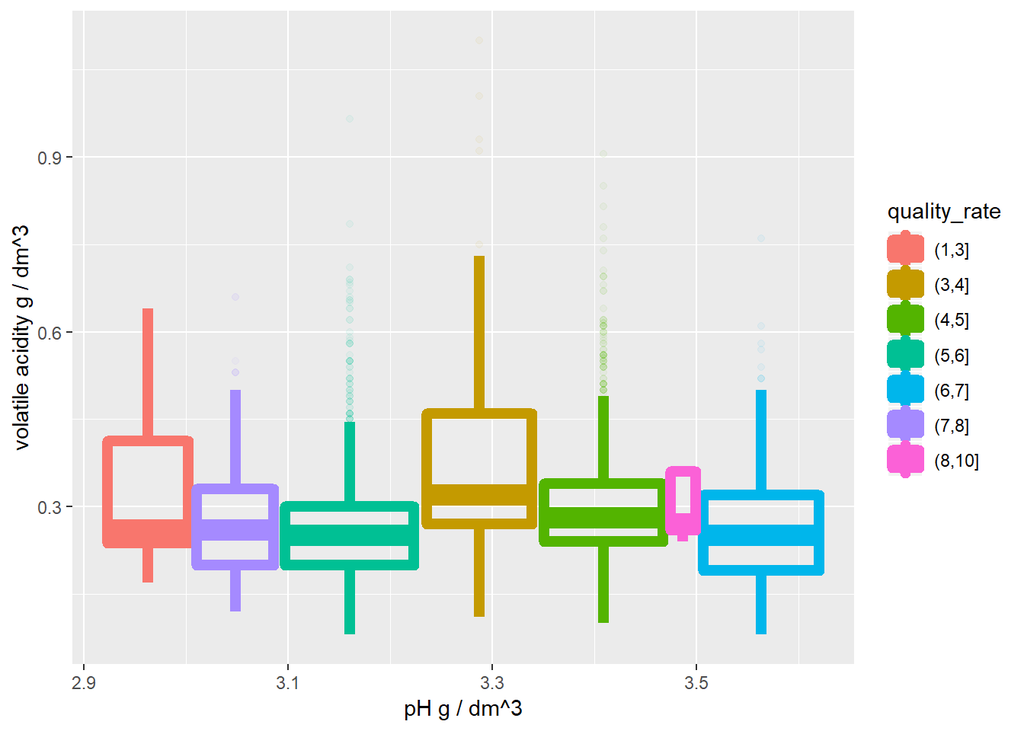

```
## $title
## [1] "volatile acidity and pH rate on each type of white wine"
##
## attr(,"class")
## [1] "labels"
```

## Reflection

### Did you meet any challenge during your analysis?

yes because when I use this data I want to find the effect and harms of drinking wine.

### what information do you need to improve your analysis?

it wil be better if the data included the effect of wine then the analysis will improving and fining out many results.